# Explorando distribuciones

## ¿Porque es necesario conocer la distribución de nuestros datos?

Muchas de las inferencias que hacemos sobre nuestros datos se basan en que estos presenta una determinada distribución sobre todo cuando asumimos una distribución normal. Es decir una desviación estandar puede implicar cosas distintas en una distribución normal, en una distribución gamma o una distribución cauchy.

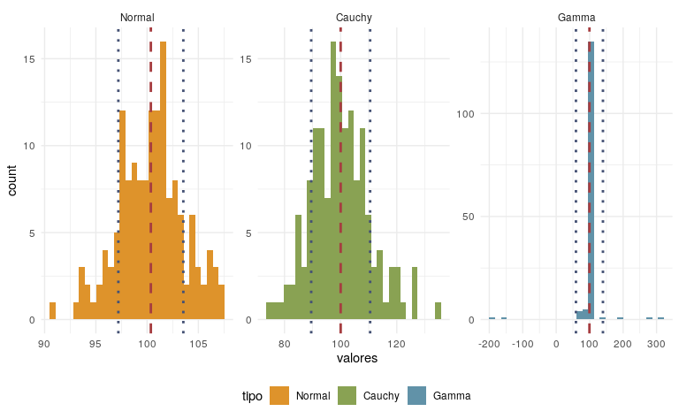

## Representación gráfica de la distribución

En general la prímera opción que tenemos al explorar la distribución de un conjunto de datos es graficarlo. Y existen muchos gráficos que nos daran distinta información cada uno.

### Histograma

Hemos hablado mucho de un histograma de los datos usando la función `hist()`. Con `ggplot2` podemos crear un histograma de forma sencilla

Creamos unos datos aleatorios a partir de una distribución normal

> **Nota:** Para que ggplot pueda usar nuestros datos tienen que estar dentro de un dataframe

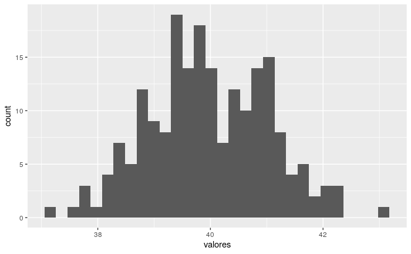

Podemos darle una apariencia más agradable con:

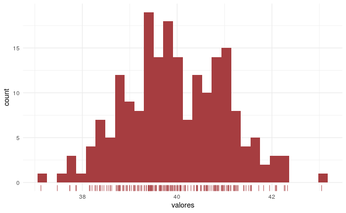

- Agregamos [colores en modo hexadecimal](https://www.color-hex.com/) aunque **R** cuenta con paletas de colores como ColorBrewer o Virids (Inluso tiene temas basados en películas de [Wes Anderson](https://cran.r-project.org/web/packages/wesanderson/index.html)).
- Quitamos color de fondo invirtiendo la cuadrícula
- Agregamos un gráfico de *“alfombra”* que nos da una idea de la ocurrencia de las observaciones.

En este caso estamos viendo el conteo de la ocurrencia de valores, pero en ocasiones esta medida puede hacer difícil la visualización de la distribución, por lo que podemos hacer representaciones de la [densidad](https://en.wikipedia.org/wiki/Kernel_density_estimation).

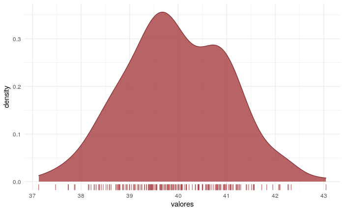

### Boxplot

La representación de los cuantiles mediante el gráfico de Boxplot nos permite conocer la dispersión y compararla rápidamente

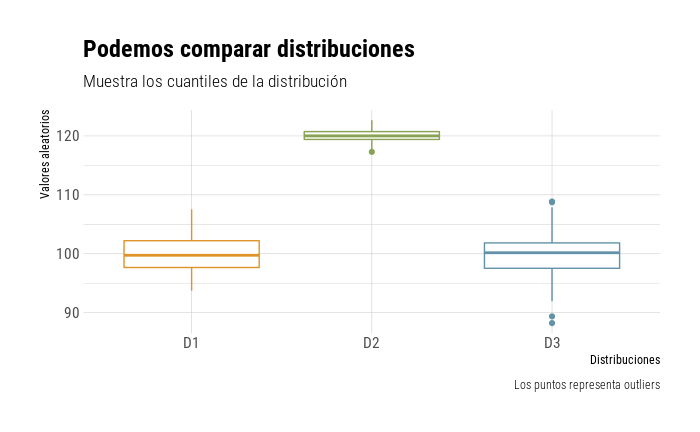

Sin embargo cuando las distribuciones tienen dispersiones o magnitudes muy diferentes la comparativa es complicada.

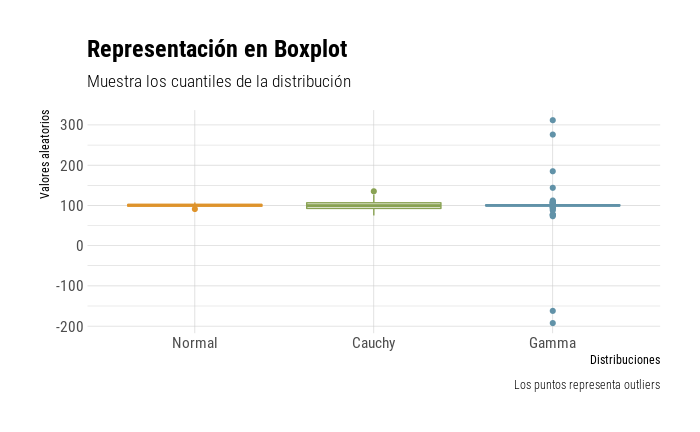

Nos podemos ayudar de una normalización de los datos graficados, sinembargo esta normalización se debe interpretar con cuidado.

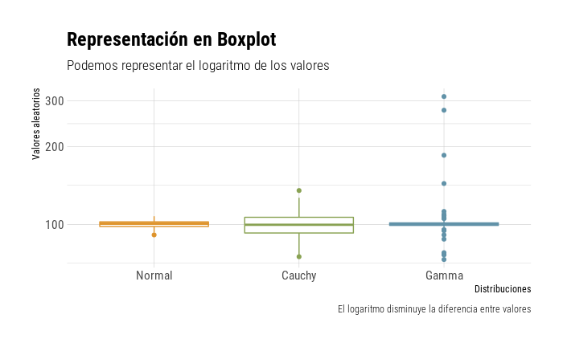

## Jitter

Si queremos revisar los datos y su dispersión directamente podemos ver los valores individuales podríamos graficar los valores en puntos, sin embargo al tener solo una variable nominal para las distribuciones un gráfico de puntos no permite ver la totalidad de los mismos.

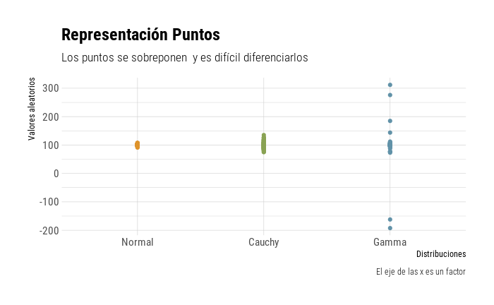

Sin embargo la geometría *jitter* al dispersar los valores sobre el eje x pero dentro de un rango contenido, permite observar mejor los puntos de la distribución

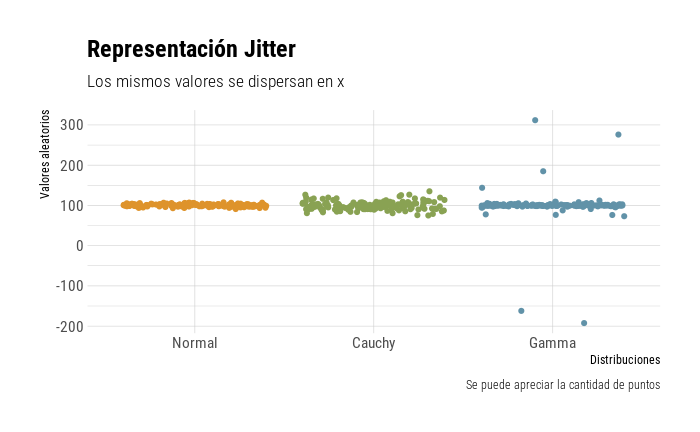

## Boxplot + Jitter

Combinando el boxplot y jitter se puede apreciar los puntos individuales y los cuantiles como una referencia de las distribución. Ademas al definir un valor alpha (transparencia que va de 0 a 1) nos permitirá ver aglomeraciones de puntos.

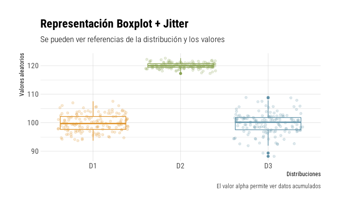